# Gene Prevalence Estimation

```r
library(tidyverse)
```

In this file we compare several estimators of gene prevalence for data with independent Bernoulli missingness by considering the mean squared error of these estimates. We then consider methods for constructing confidences intervals based on these estimators and check their nominal coverage and compare their widths. We then check how robust these confidence intervals are to model misspecification, either with errors in the observed completeness parameters or with per-gene bias in the missingness.

# 1 Setup

We observe a binary matrix $X\in\{0,1\}^{n\times p}$ where $n$ is the number of genomes and $p$ is the number of genes.

$$X_{ij}=Y_{ij}\cdot Z_{ij}$$
where $Y_{ij}\sim\text{Bernoulli}(\pi_j)$ is the true presence/absence of gene $j$ in genome $i$ and $Z_{ij}\sim\text{Bernoulli}(\lambda_i)$ indicates whether gene $j$ is detected in genome $i$. Here, $\lambda_i$ is the known[^1] detection probability for genes within genome $i$. We assume independence of all of these Bernoulli variables.

Thus, $X_{ij}\sim\text{Bernoulli}(\lambda_i\pi_j)$.

**Goal:** Estimate the gene prevalences $\pi_j$ for $j=1,\ldots,p$. We assume that the detection probabilities $\lambda_i$ are known for $i=1,\ldots,n$.

```r
simulate_data <- function(pi, lambda) {
  n <- length(lambda)
  p <- length(pi)
  Y <- matrix(rbinom(n * p, 1, rep(pi, each = n)), nrow = n, ncol = p)
  Z <- matrix(rbinom(n * p, 1, rep(lambda, times = p)), nrow = n, ncol = p)
  list(X = Y * Z, Y = Y, Z = Z)
}
```

Let’s generate some example data.

```r
set.seed(123)
lambda <- c(rep(1, 40), rep(c(0.8, 0.6, 0.4, 0.2), each = 100))
pi <- c(rep(1, 1000), rep(0.5, 2500), rep(0.2, 6000), rep(0.01, 500))
ex1 <- c(
  simulate_data(pi, lambda),
  pi = list(pi),
  lambda = list(lambda)
  )
```

# 2 Estimating $\pi_j$

## 2.1 Unbiased estimator

An unbiased estimate for $\pi_j$ is given by

$$\widehat{\pi}_j = \frac1{n} \sum_{i=1}^n \frac1{{\lambda_i}}X_{ij}.$$

To see that it is unbiased, note that $\mathbb{E}[X_{ij}]=\pi_j\lambda_i$.

If we like, we can improve this estimator by ensuring it is never above 1 (although we lose unbiasedness by doing so, we can with lower variance):

```r
estimate_pi <- function(X, lambda, clip = FALSE) {
  pi_hat <- colMeans(X / lambda)
  if (clip) pi_hat <- pmin(pi_hat, 1)
  return(pi_hat)
}
```

## 2.2 Maximum Likelihood Estimation of $\pi_j$

An alternative is to consider maximizing the likelihood function of each parameter $\pi_j$. Because $p^{X} = p$ if $X = 1$ and $p^X = 1$ if $X = 0$, we can write express the likelihood as:

$$\begin{align}
L( \pi_j \mid X, \lambda ) &= \prod_{i = 1}^n \mathbb{P}( X_{ij} =1
)^{ X_{ij} } \times \mathbb{P}( X_{ij} = 0)^{1 - X_{ij}} \\
&= \prod_{i = 1}^n (\pi_j \lambda_i) ^{ X_{ij} } (
1 - \pi_j \lambda_i )^{1 - X_{ij}}
\end{align}$$
We can maximize this directly, or maximize the log-likelihood, which splits the products into sums and the exponents into multiplicative factors.
$$\ell( \pi_j \mid X, \lambda ) = \log L( \pi_j \mid X, \lambda ) =
\sum_{i = 1}^n X_{ij} \log ( \pi_j \lambda_i) + ( 1 - X_{ij} ) \log ( 1
- \pi_j \lambda_i )$$
We can also finding the maximum by considering the derivative in $\pi_j$, and setting it equal to 0:
$$\sum_{i=1}^n \left[\frac{X_{ij}}{\pi_j} - \lambda_i
\frac{1-X_{ij}}{1-\lambda_i\pi_j}\right] = 0.$$
Doing any of these optimizations numerically using `uniroot` or `optim` in R to give an estimator $\widehat{\pi}_j^{MLE}$. Note that the log-likelihood can be undefined if $\pi_j \lambda_i = 0$ or $1$, and so in the code below we “pad” the probability matrix with a $10^{-8}$ buffer for numerical stability. (N.B., the gene_copies code here is used only to adapt this likelihood to the case where there are multiple copies of each gene present on each genome, discussed in the model misspecification section later).

```r
add_epsilon <- function(mat, epsilon = 1e-8) {
    mat <- pmax(mat, epsilon)
    mat <- pmin(mat, 1 - epsilon)
    return(mat)
}

estimate_pi_mle_optim <- function( data, lambdas, gene_copies = NULL, hessians = FALSE ) {
  pi_hats <- rep(0, dim(data)[2] )
  likelihoods <- rep(0, dim(data)[2] )
  if (is.null(gene_copies)) {gene_copies = rep(1, dim(data)[2])}
  if (hessians) { hessian_vals <- rep(0, dim(data)[2] )  }
  if (!is.matrix(lambdas)) {lambdas <- matrix(lambdas, nrow = nrow(data), ncol = ncol(data))}

  for (j in 1:dim(data)[2]) {
    data_j <- data[,j]
    lambdas_j <- lambdas[,j]
    gene_copies_j <- gene_copies[j]
    nll <- function( pi_j ) {
      p_mat <- pi_j * ( 1 - (1 - lambdas_j)^gene_copies_j )
      return( - sum( data_j*log(add_epsilon(p_mat)) + (1-data_j)*log(add_epsilon(1-p_mat))))
    }
    results <- optim( c(0.5),
                         nll,
                         method = "L-BFGS-B",
                         lower = 0,
                         upper = 1,
                         hessian = hessians)
    pi_hats[j] <- results$par
    likelihoods[j] <- results$value
    if (hessians) {
      hessian_vals <- results$hessian
    }
  }
  if (hessians) {return(list(pi_hats=pi_hats,values=likelihoods,hessian_vals=hessian_vals))}
  return(  list( pi_hats = pi_hats, values = likelihoods) )
}

estimate_pi_mle_ests <- function( data, lambdas ){
  return( estimate_pi_mle_optim(data, lambdas)$pi_hats )
}
```

## 2.3 Comparing to two baselines

Let’s apply these two approaches to our example, and compare to the following baselines:

- Naive approach: just take the average prevalence across all genomes, both complete and incomplete, and ignore any potential missingness.; and
- Standard approach: throw out all incomplete genomes and then estimate $\pi_j$ as the proportion of complete genomes in which gene $j$ is detected. This approach, while unbiased, will usually have higher variance because it does not use all of the information in the incomplete genomes to estimate $\pi_j$.

```r
system.time({pi_hat <- estimate_pi(ex1$X, lambda, clip = FALSE)})
```

```
##    user  system elapsed
##   0.212   0.074   9.957
```

```r
pi_hat_clipped <- estimate_pi(ex1$X, lambda, clip = TRUE)
pi_hat_naive <- colMeans(ex1$X)
pi_hat_complete <- colMeans(ex1$X[lambda==1,])
system.time(pi_hat_mle_optim <- estimate_pi_mle_optim(ex1$X, lambda, rep(1, dim(ex1$X)[2])) )
```

```
##    user  system elapsed
##   5.478   0.465   5.959
```

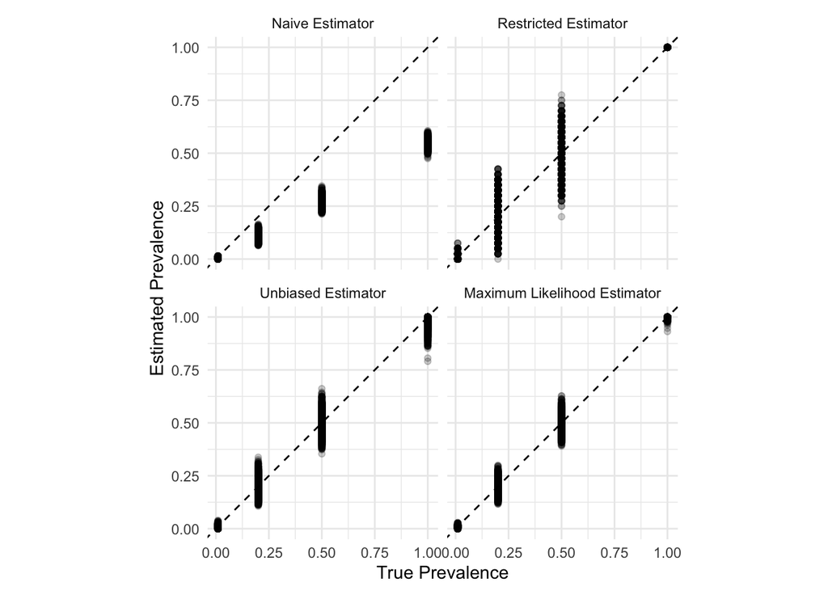

```r
all_pi <- tibble(
  pi_hat_clipped = pi_hat_clipped,
  pi_hat_naive = pi_hat_naive,
  pi_hat_complete = pi_hat_complete,
  pi_hat_mle_optim = pi_hat_mle_optim$pi_hats,
  pi_true = ex1$pi)

estimator_labels <- c(
  pi_hat_clipped    = "Unbiased Estimator",
  pi_hat_naive      = "Naive Estimator",
  pi_hat_complete   = "Restricted Estimator",
  pi_hat_mle_optim  = "Maximum Likelihood Estimator"
)

all_pi %>%
  pivot_longer(-pi_true, names_to = "estimator", values_to = "estimate") %>%
  mutate(estimator = factor(estimator, levels = c(
    "pi_hat_naive",
    "pi_hat_complete",
    "pi_hat_clipped",
    "pi_hat_mle_optim"
  ))) %>%
  ggplot(aes(x = pi_true, y = estimate)) +
  geom_point(alpha = 0.2) +
  geom_abline(slope = 1, intercept = 0, linetype = "dashed") +
  facet_wrap(~estimator, labeller = labeller(estimator = estimator_labels)) +
  labs(x = "True Prevalence", y = "Estimated Prevalence") +
  theme_minimal() +
  coord_equal()
```

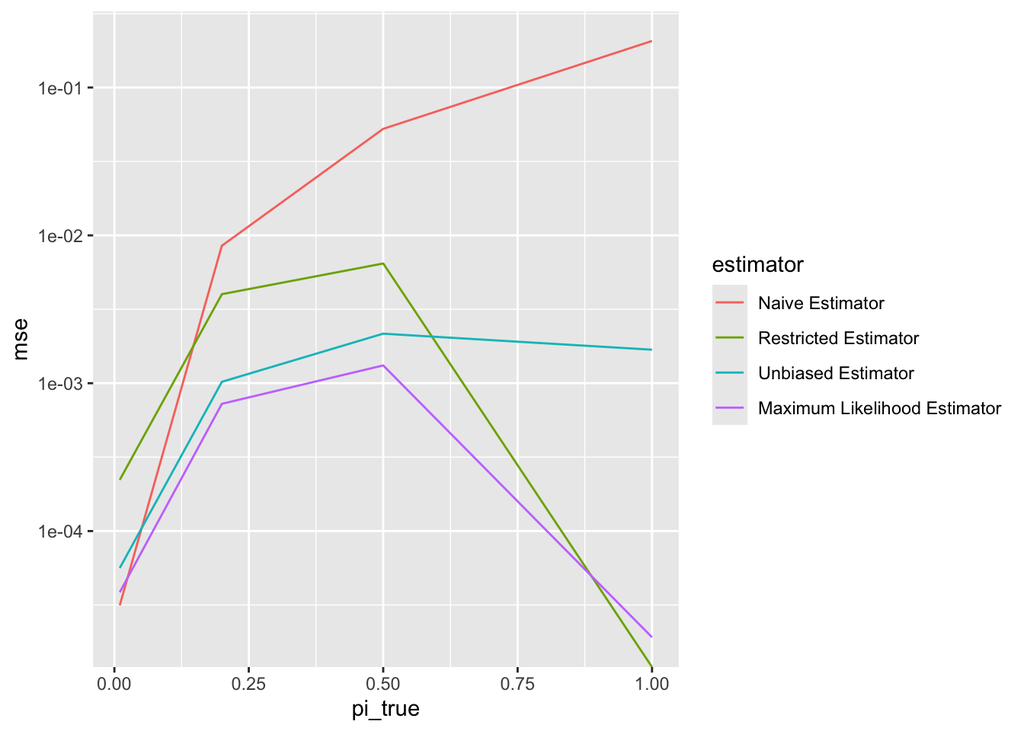

```r
all_pi %>%
  pivot_longer(-pi_true, names_to = "estimator", values_to = "estimate") %>%
  mutate(estimator = factor(estimator, levels = c(
    "pi_hat_naive",
    "pi_hat_complete",
    "pi_hat_clipped",
    "pi_hat_mle_optim"
  ))) %>%
  group_by(estimator, pi_true) %>%
  summarize(mse = mean((estimate - pi_true)^2), .groups = "drop") %>%
  ggplot(aes(x=pi_true, y=mse, color = estimator)) +
  geom_line() +
  scale_y_log10() +
  scale_color_discrete(labels = estimator_labels)
```

Overall the MLE is the best performing estimator for most intermediate prevalence genes. Extreme prevalence genes (with $\pi_j$ close to 0 or 1) lead to slightly worse performance for the MLE because this is where it is hardest to account for missingness.

# 3 Confidence intervals for $\pi_j$

We consider six methods for constructing confidence intervals. Two are simple and based on the location and estimated variance of the unbiased estimator. One is based on the likelihood ratio test and relies on the asymptotics of the likelihood ratio. Two are exact tests based on inverting a permutation test for a hypothesized parameters, one variant of this uses the unbiased estimator and one uses the MLE. Lastly, we consider a bootstrapping approach to form a CI.  
We consider each of these tests performed on three different subsets of the data: (1) using only the complete genomes (tagged with _complete); (2) using all of the data; and (3) using the genomes with (observed) completeness at least 0.25 (tagged with _filtered).

## 3.1 Normal approximation

The variance of this estimator is given by

```r
estimate_pi_var <- function(X, lambda, pi_hat) {
  n <- nrow(X)
  pi_hat * (sum(1 / lambda) - pi_hat * sum(lambda) ) / n^2
}
```

If we assume that $\widehat{\pi}_j$ is approximately normally distributed then a $100(1-\alpha)\%$ confidence interval for $\pi_j$ can be constructed as

$$\widehat{\pi}_j \pm z_{1-\alpha/2}
\sqrt{\widehat{\text{Var}}(\widehat{\pi}_j)}.$$
Here, $\widehat{\text{Var}}(\widehat{\pi}_j)$ is the plug-in estimator for the variance, obtained by replacing $\pi_j$ with $\widehat{\pi}_j$ in the variance formula.

```r
normal_ci <- function(X, lambda, alpha = 0.05) {
  pi_hat <- estimate_pi(X, lambda)
  se <- sqrt(estimate_pi_var(X, lambda, pi_hat))
  z <- qnorm(1 - alpha / 2)
  list(lower = pi_hat - z * se, upper = pi_hat + z * se)
}

normal_ci_complete <- function(X, lambda, alpha = 0.05) {
  normal_ci(X[lambda == 1, ], lambda[lambda == 1], alpha)
}

normal_ci_filtered <- function(X, lambda, threshold = 0.25, alpha = 0.05) {
  normal_ci(X[lambda > threshold, ], lambda[lambda  > threshold], alpha)
}
```

## 3.2 Chebyshev

Using Chebyshev’s inequality, we can construct a confidence interval for $\pi_j$ as
$$\widehat{\pi}_j \pm
\sqrt{\frac{\widehat{\text{Var}}(\widehat{\pi}_j)}{\alpha}}.$$
This interval is guaranteed to have coverage of at least $1-\alpha$, regardless of the distribution of $\widehat{\pi}_j$, but it may be overly conservative.

```r
chebyshev_ci <- function(X, lambda, alpha = 0.05) {
  pi_hat <- estimate_pi(X, lambda)
  half_width <- sqrt(estimate_pi_var(X, lambda, pi_hat) / alpha)
  list(lower = pi_hat - half_width, upper = pi_hat + half_width)
}

chebyshev_ci_complete <- function(X, lambda, alpha = 0.05) {
  chebyshev_ci(X[lambda == 1, ], lambda[lambda == 1], alpha)
}

chebyshev_ci_filtered <- function(X, lambda, threshold = 0.25, alpha = 0.05) {
  chebyshev_ci(X[lambda > threshold, ], lambda[lambda  > threshold], alpha)
}
```

## 3.3 Likelihood Ratio Test

We can appeal to the asymptotic of the MLE theory to define the confidence region in terms of the possible parameters $\pi_j$ for which

$$\ell( \widehat{\pi}_j^{MLE} \mid X, \lambda ) - \ell( \pi_j \mid X,
\lambda ) < \frac{ q_{1 - \alpha} }{2}$$

where $q_{1-\alpha}$ is the $1-\alpha$ quantile of a $\chi_1^2$ distribution. Computationally, we will compute the values of $\ell(\pi \mid X, \lambda)$ on a grid of possible $\pi$ values. (N.B., the gene_copies code here is used only to adapt this likelihood to the case where there are multiple copies of each gene present on each genome, discussed in the model misspecification section later.)

```r
lr_ci <- function(X, lambdas, gene_copies = NULL, alpha = 0.05, pi_grid = seq(0.000, 1.000, by = 0.001)) {

  if (is.null(gene_copies)) { gene_copies = rep(1,dim(X)[2]) }
  if (!is.matrix(lambdas)) {lambdas <- matrix(lambdas, nrow = nrow(X), ncol = ncol(X))}

  ests <- estimate_pi_mle_optim(X, lambdas, gene_copies)
  pi_hats <- ests$pi_hats
  mle_nllikelihoods <- matrix(ests$values, nrow=length(pi_grid), ncol=dim(X)[2], byrow=TRUE)
  q <- qchisq(1-alpha, 1)

  nllikelihoods <- matrix( 0, nrow = length( pi_grid ), ncol = dim(X)[2] )

  for (j in 1:dim(X)[2]) {
    data_j <- X[,j]
    lambdas_j <- lambdas[,j]
    gene_copy_number_j <- gene_copies[j]
    nll_j <- function( pi_j ) {
      p_mat <- pi_j * (1 - (1 - lambdas_j)^gene_copy_number_j )
      return( - sum( data_j*log(add_epsilon(p_mat)) + (1-data_j)*log(add_epsilon(1-p_mat))))
    }
    nllikelihoods[,j] <- sapply( pi_grid, nll_j )
  }

  ci_region_locs <- 2*( nllikelihoods - mle_nllikelihoods ) < q

  hi <- apply( ci_region_locs * pi_grid, 2, max )
  lo <- apply( ci_region_locs*pi_grid + 5*(1 - ci_region_locs), 2, min )

  list(lower = lo , upper = hi)
}

lr_ci_complete <- function(X, lambdas, gene_copies = NULL, alpha = 0.05) {
  if (!is.matrix(lambdas)) {lambdas <- matrix(lambdas, nrow = nrow(X), ncol = ncol(X))}
  row_inds <- which(apply(lambdas == 1, 1, all))
  lr_ci(X[row_inds, ], lambdas[row_inds,], gene_copies, alpha)
}

lr_ci_filtered <- function(X, lambdas, gene_copies = NULL, threshold = 0.25, alpha = 0.05) {
  if (!is.matrix(lambdas)) {lambdas <- matrix(lambdas, nrow = nrow(X), ncol = ncol(X))}
  row_inds <- which(apply(lambdas > 0.25, 1, all))
  lr_ci(X[row_inds, ], lambdas[row_inds,], gene_copies, alpha)
}
```

## 3.4 Inverting exact test

We use the fact that a confidence interval for $\pi_j$ is the set of all values $\widetilde\pi$ such that a test of $H_0:\pi_j=\widetilde\pi$ vs. $H_a:\pi_j\neq\widetilde\pi$ would not be rejected at level $\alpha$. We can perform this test by computing the test statistic $\widehat\pi_j$ and comparing it to the distribution of $\widehat\pi_j$ under the null hypothesis, which can be obtained by simulating data under $H_0$ (i.e., simulating $X_{ij}\sim\text{Bernoulli}(\lambda_i\widetilde\pi)$ for $i=1,\ldots,n$) and recalculating $\widehat\pi_j$ for each simulated dataset. The confidence interval is then the set of all $\widetilde\pi$ values for which the observed $\widehat\pi_j$ falls within the acceptance region of the test. This is true for any estimator, whether the unbiased or the MLE.

Computational note: Given that the null distribution does not depend on $j$, we can reuse the work across genes when constructing confidence intervals using the inverting exact test method. Along a fine grid of $\widetilde{\pi}$ values, for each draw from the null distribution we can check across all $j$ whether the observed $\widehat\pi_j$ falls within the acceptance region for that $\widetilde{\pi}$ value, and then construct confidence intervals for all genes simultaneously.

```r
invert_test_ci <- function(X, lambda, alpha = 0.05,
                           pi_grid = seq(0.000, 1.000, by = 0.001),
                           B = 1000, pi_estimator = estimate_pi) {
  pi_hat <- pmin( pi_estimator(X, lambda), 1)
  n <- nrow(X)
  in_ci <- matrix(FALSE, nrow = length(pi_hat), ncol = length(pi_grid))
  for (k in seq_along(pi_grid)) {
    pi_tilde <- pi_grid[k]
    null_pi_hat <- replicate(B, pi_estimator( matrix( rbinom(n, 1, pi_tilde*lambda), ncol = 1 ), lambda ) )
    lo <- quantile(null_pi_hat, alpha / 2)
    hi <- quantile(null_pi_hat, 1 - alpha / 2)
    in_ci[, k] <- pi_hat >= lo & pi_hat <= hi
  }
  list(
    lower = apply(in_ci, 1, function(x) if (any(x)) min(pi_grid[x]) else NA),
    upper = apply(in_ci, 1, function(x) if (any(x)) max(pi_grid[x]) else NA)
  )
}

invert_test_ci_complete <- function(X, lambda, alpha = 0.05,
                                    pi_grid = seq(0.000, 1.000, by = 0.001),
                                    B = 1000, pi_estimator = estimate_pi) {
  invert_test_ci(X[lambda == 1, ], lambda[lambda == 1], alpha, pi_grid, B, pi_estimator)
}

invert_test_ci_filtered <- function(X, lambda, threshold = 0.25, alpha = 0.05,
                                    pi_grid = seq(0.000, 1.000, by = 0.001),
                                    B = 1000, pi_estimator = estimate_pi) {
  invert_test_ci(X[lambda > threshold, ], lambda[lambda > threshold], alpha, pi_grid, B, pi_estimator)
}
```

## 3.5 Bootstrap

We can use the non-parametric bootstrap to construct confidence intervals. This involves resampling the rows of $X$ with replacement, recalculating $\widehat{\pi}_j$ for each bootstrap sample, and then using the empirical distribution of these bootstrap estimates to construct confidence intervals (e.g., using the percentile method).

```r
bootstrap_ci <- function(X, lambda, alpha = 0.05, B = 1000) {
  n <- nrow(X)
  boot_pi_hat <- replicate(B, {
    idx <- sample(n, replace = TRUE)
    estimate_pi(X[idx, ], lambda[idx])
  })
  list(
    lower = apply(boot_pi_hat, 1, quantile, probs = alpha / 2),
    upper = apply(boot_pi_hat, 1, quantile, probs = 1 - alpha / 2)
  )
}

bootstrap_ci_complete <- function(X, lambda, alpha = 0.05, B = 1000) {
  bootstrap_ci(X[lambda == 1, ], lambda[lambda == 1], alpha, B)
}

bootstrap_ci_filtered <- function(X, lambda, threshold = 0.25, alpha = 0.05, B = 1000) {
  bootstrap_ci(X[lambda > threshold, ], lambda[lambda > threshold], alpha, B)
}
```

## 3.6 Comparing to baseline

In this section, we apply the different CI methods described above to the example data. We also compare to a baseline that only uses complete genomes.

```r
make_ci_df <- function(ci, method, variant, pi_true) {
  tibble(
    pi_true = pi_true,
    method  = method,
    variant = variant,
    ci_lower = ci$lower,
    ci_upper = ci$upper,
    covered = pi_true >= ci$lower & pi_true <= ci$upper,
    length  = ci$upper - ci$lower
  )
}
```

```r
run_cis <- function( ex1 ) {

  print("Normal CIs")
  print(system.time({ ci_normal             <- normal_ci(ex1$X, ex1$lambda) }))
  print(system.time({ ci_normal_complete    <- normal_ci_complete(ex1$X, ex1$lambda) }))
  print(system.time({ ci_normal_filtered    <- normal_ci_filtered(ex1$X, ex1$lambda) }))
  print("Chebyshev CIs")
  print(system.time({ ci_chebyshev          <- chebyshev_ci(ex1$X, ex1$lambda) }))
  print(system.time({ ci_chebyshev_complete <- chebyshev_ci_complete(ex1$X, ex1$lambda) }))
  print(system.time({ ci_chebyshev_filtered <- chebyshev_ci_filtered(ex1$X, ex1$lambda) }))
  print("Likelihood Ratio CIs")
  print(system.time({ ci_lr                 <- lr_ci(ex1$X, ex1$lambda, rep(1, dim(ex1$X)[2]) ) }))
  print(system.time({ ci_lr_complete        <- lr_ci_complete(ex1$X, ex1$lambda, rep(1, dim(ex1$X)[2])) }))
  print(system.time({ ci_lr_filtered        <- lr_ci_filtered(ex1$X, ex1$lambda, rep(1, dim(ex1$X)[2])) }))
  print("Exact Permutation CIs, using Unbiassed Est")
  print(system.time({ ci_invert             <- invert_test_ci(ex1$X, ex1$lambda) }))
  print(system.time({ ci_invert_complete    <- invert_test_ci_complete(ex1$X, ex1$lambda) }))
  print(system.time({ ci_invert_filtered    <- invert_test_ci_filtered(ex1$X, ex1$lambda) }))
  print("Exact Permutation CIs, Using MLEs")
  print(system.time({ ci_invert_mle         <- invert_test_ci(ex1$X, ex1$lambda,
                                                        pi_estimator = estimate_pi_mle_ests) }))
  print(system.time({ ci_invert_complete_mle<- invert_test_ci_complete(ex1$X, ex1$lambda,
                                                                 pi_estimator = estimate_pi_mle_ests) }))
  print(system.time({ ci_invert_filtered_mle<- invert_test_ci_filtered(ex1$X, ex1$lambda,
                                                                 pi_estimator = estimate_pi_mle_ests) }))
  print("Bootstrap CIs")
  print(system.time({ ci_boot               <- bootstrap_ci(ex1$X, ex1$lambda) }))
  print(system.time({ ci_boot_complete      <- bootstrap_ci_complete(ex1$X, ex1$lambda) }))
  print(system.time({ ci_boot_filtered      <- bootstrap_ci_filtered(ex1$X, ex1$lambda) }))

  ci_df <- bind_rows(
  make_ci_df(ci_normal,                 "normal",      "all",      ex1$pi),
  make_ci_df(ci_normal_complete,        "normal",      "complete", ex1$pi),
  make_ci_df(ci_normal_filtered,        "normal",      "filtered", ex1$pi),
  make_ci_df(ci_chebyshev,              "chebyshev",   "all",      ex1$pi),
  make_ci_df(ci_chebyshev_complete,     "chebyshev",   "complete", ex1$pi),
  make_ci_df(ci_chebyshev_filtered,     "chebyshev",   "filtered", ex1$pi),
  make_ci_df(ci_lr,                     "likelihood",  "all",      ex1$pi),
  make_ci_df(ci_lr_complete,            "likelihood",  "complete", ex1$pi),
  make_ci_df(ci_lr_filtered,            "likelihood",  "filtered", ex1$pi),
  make_ci_df(ci_invert,                 "invert_test", "all",      ex1$pi),
  make_ci_df(ci_invert_complete,        "invert_test", "complete", ex1$pi),
  make_ci_df(ci_invert_filtered,        "invert_test", "filtered", ex1$pi),
  make_ci_df(ci_invert_mle,             "invert_mle",  "all",      ex1$pi),
  make_ci_df(ci_invert_complete_mle,    "invert_mle",  "complete",  ex1$pi),
  make_ci_df(ci_invert_filtered_mle,    "invert_mle",  "filtered",  ex1$pi),
  make_ci_df(ci_boot,                   "bootstrap",   "all",      ex1$pi),
  make_ci_df(ci_boot_complete,          "bootstrap",   "complete", ex1$pi),
  make_ci_df(ci_boot_filtered,          "bootstrap",   "filtered", ex1$pi)
  )
  return(ci_df)
}

ci_df <- run_cis( ex1 )
```

```
## [1] "Normal CIs"
##    user  system elapsed
##   0.253   0.021   3.206
##    user  system elapsed
##   0.009   0.000   0.010
##    user  system elapsed
##   0.010   0.001   0.012
## [1] "Chebyshev CIs"
##    user  system elapsed
##   0.009   0.002   0.013
##    user  system elapsed
##   0.004   0.000   0.004
##    user  system elapsed
##   0.009   0.002   0.011
## [1] "Likelihood Ratio CIs"
##    user  system elapsed
## 273.026   7.302 281.974
##    user  system elapsed
## 143.433   2.411 146.763
##    user  system elapsed
## 241.860   6.970 249.869
## [1] "Exact Permutation CIs, using Unbiassed Est"
##    user  system elapsed
##  12.719   0.360  13.379
##    user  system elapsed
##   4.998   0.104   5.121
##    user  system elapsed
##  10.878   0.217  11.145
## [1] "Exact Permutation CIs, Using MLEs"
##    user  system elapsed
## 870.323  23.176 895.287
##    user  system elapsed
## 471.414   7.504 479.730
##    user  system elapsed
## 770.669  19.567 791.646
## [1] "Bootstrap CIs"
##    user  system elapsed
##  14.742   2.006  16.801
##    user  system elapsed
##   2.195   0.208   2.426
##    user  system elapsed
##  11.402   1.589  13.028
```

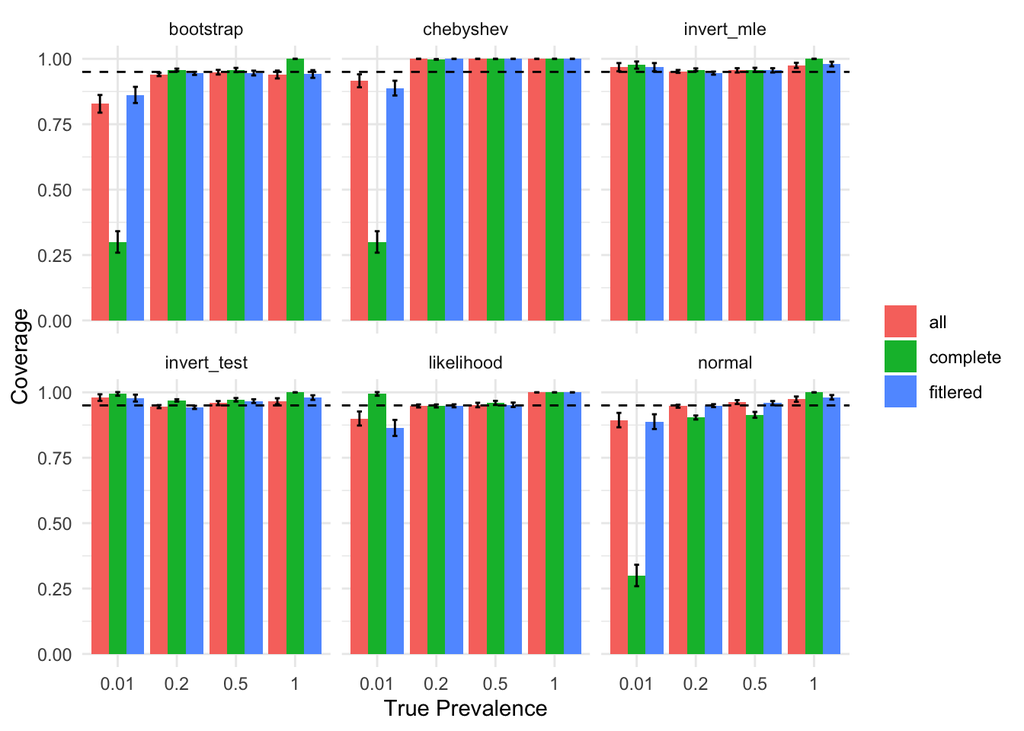

```r
ci_df %>%
  group_by(method, variant, pi_true) %>%
  summarize(coverage = mean(covered, na.rm = TRUE),
            se = sqrt(coverage * (1-coverage) / n()),
            .groups = "drop") %>%
  ggplot(aes(x = factor(pi_true), y = coverage, fill = variant)) +
  geom_col(position = "dodge") +
  geom_errorbar(aes(ymin = coverage - 2 * se, ymax = coverage + 2 * se),
                position = position_dodge(width = 0.9), width = 0.25) +
  geom_hline(yintercept = 0.95, linetype = "dashed") +
  facet_wrap(~method) +
  labs(x = "True Prevalence", y = "Coverage", fill = NULL) +
  theme_minimal()
```

The next plot shows that in terms of the length of intervals, using all genomes rather than only complete ones leads to shorter intervals except when the true prevalence is 1.

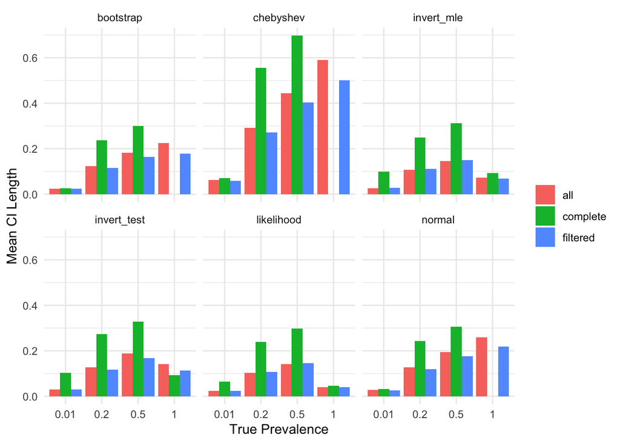

```r
ci_df %>%
  group_by(method, variant, pi_true) %>%
  summarize(mean_length = mean(length, na.rm = TRUE), .groups = "drop") %>%
  ggplot(aes(x = factor(pi_true), y = mean_length, fill = variant)) +
  geom_col(position = "dodge") +
  facet_wrap(~method) +
  labs(x = "True Prevalence", y = "Mean CI Length", fill = NULL) +
  theme_minimal()
```

## 3.7 Genes that are never observed

Part of the reason that these tests fail to achieve nominal coverage at the low prevalence end is that it is possible to never observe a gene. If we consider the coverage for these tests on only the genes that are observed at least once, and also at least once in the complete genomes, we see that these tests achieve their nominal coverage. It is worth considering how we should treat genes that have not been observed more thoroughly.

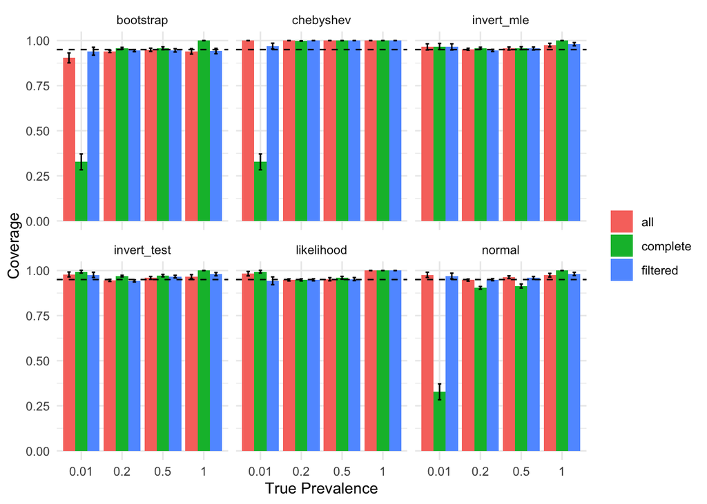

```r
observed_genes <- which(colSums( ex1$X ) > 0)
row_inds <- sort(as.vector(outer(observed_genes, seq(0, 170000, by = 10000), "+")))

ci_df[row_inds,] %>%
  group_by(method, variant, pi_true) %>%
  summarize(coverage = mean(covered, na.rm = TRUE),
            se = sqrt(coverage * (1-coverage) / n()),
            .groups = "drop") %>%
  ggplot(aes(x = factor(pi_true), y = coverage, fill = variant)) +
  geom_col(position = "dodge") +
  geom_errorbar(aes(ymin = coverage - 2 * se, ymax = coverage + 2 * se),
                position = position_dodge(width = 0.9), width = 0.25) +
  geom_hline(yintercept = 0.95, linetype = "dashed") +
  facet_wrap(~method) +
  labs(x = "True Prevalence", y = "Coverage", fill = NULL) +
  theme_minimal()
```

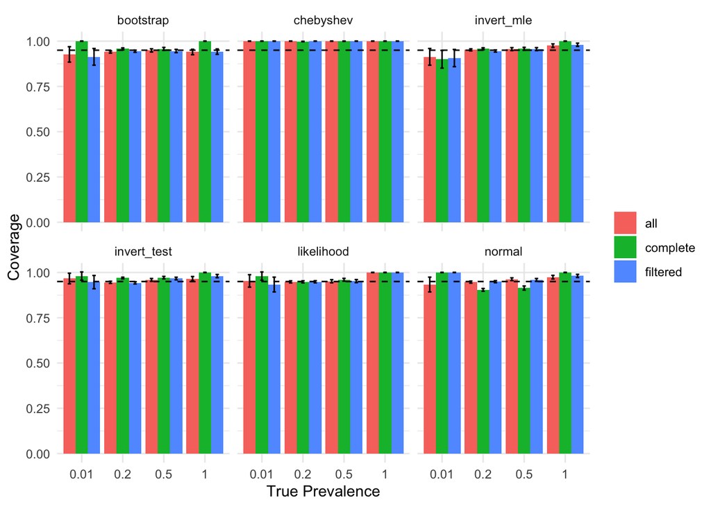

```r
complete_observed_genes <-  which( t(ex1$X) %*% (lambda == 1) > 0 )
row_inds <- sort(as.vector(outer(complete_observed_genes, seq(0, 170000, by = 10000), "+")))

ci_df[row_inds,] %>%
  group_by(method, variant, pi_true) %>%
  summarize(coverage = mean(covered, na.rm = TRUE),
            se = sqrt(coverage * (1-coverage) / n()),
            .groups = "drop") %>%
  ggplot(aes(x = factor(pi_true), y = coverage, fill = variant)) +
  geom_col(position = "dodge") +
  geom_errorbar(aes(ymin = coverage - 2 * se, ymax = coverage + 2 * se),
                position = position_dodge(width = 0.9), width = 0.25) +
  geom_hline(yintercept = 0.95, linetype = "dashed") +
  facet_wrap(~method) +
  labs(x = "True Prevalence", y = "Coverage", fill = NULL) +
  theme_minimal()
```

# 4 Testing Robustness to Model Failures

## 4.1 Errors in Lambda

The completeness values used come from an estimate $\widehat{\lambda_i}$ based on $m$ core genes, where $\pi_j$ is known to be 1. This means that these used are actually a random variable based on the finite sample of core genes, with known distribution with $\widehat{\lambda_i} m \sim Binomial( m, \lambda_i)$. If we simulate data as before and rerun the simulations we see that the tests are mostly robust to this kind of error, even though the observed $\widehat{\lambda}_i$ can differ significantly from the underlying missingness $\lambda_i$. (N.B. the simulations of $\widehat{\lambda}_i$ below are slightly different to avoid 0s).

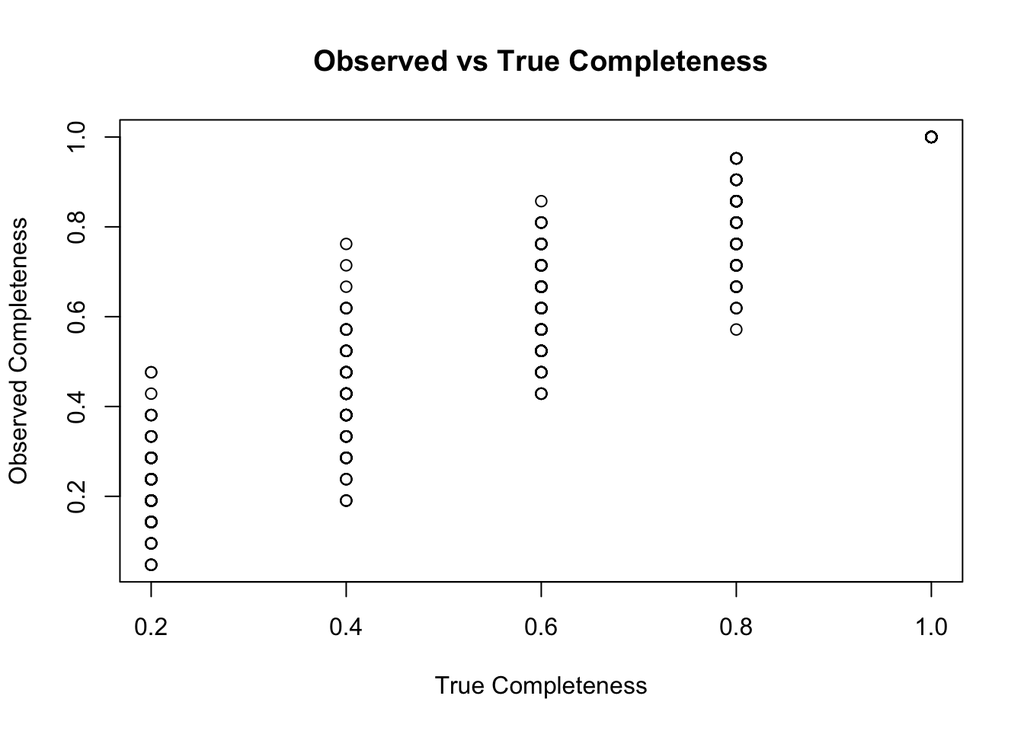

```r
set.seed(123)
lambda <- c(rep(1, 40), rep(c(0.8, 0.6, 0.4, 0.2), each = 100))
pi <- c(rep(1, 1000), rep(0.5, 2500), rep(0.2, 6000), rep(0.01, 500))
m_core_genes <- 20
ex2 <- c(
  simulate_data(pi, lambda),
  pi = list(pi),
  lambda = list( (1 + rbinom(length(lambda), m_core_genes, lambda) ) / (m_core_genes + 1) )
  )

plot( lambda, ex2$lambda, type = "p", xlab = "True Completeness", ylab = "Observed Completeness", main = "Observed vs True Completeness" )
```

```r
ci_df_2 <- run_cis( ex2 )
```

```
## [1] "Normal CIs"
##    user  system elapsed
##   0.009   0.001   0.009
##    user  system elapsed
##   0.004   0.000   0.004
##    user  system elapsed
##   0.012   0.002   0.014
## [1] "Chebyshev CIs"
##    user  system elapsed
##   0.009   0.001   0.010
##    user  system elapsed
##   0.005   0.001   0.005
##    user  system elapsed
##   0.013   0.002   0.015
## [1] "Likelihood Ratio CIs"
##    user  system elapsed
## 112.127  11.465 125.602
##    user  system elapsed
##  32.582   2.345  35.714
##    user  system elapsed
##  95.920   9.382 106.821
## [1] "Exact Permutation CIs, using Unbiassed Est"
##    user  system elapsed
##  14.384   0.361  14.927
##    user  system elapsed
##   5.799   0.126   6.015
##    user  system elapsed
##  13.438   0.287  13.940
## [1] "Exact Permutation CIs, Using MLEs"
##    user  system elapsed
## 382.333  36.691 425.253
##    user  system elapsed
##   5.470   0.120   5.638
##    user  system elapsed
##  12.806   0.271  13.195
## [1] "Bootstrap CIs"
##    user  system elapsed
##  15.227   2.458  17.900
##    user  system elapsed
##   2.324   0.259   2.630
##    user  system elapsed
##  13.328   2.205  15.908
```

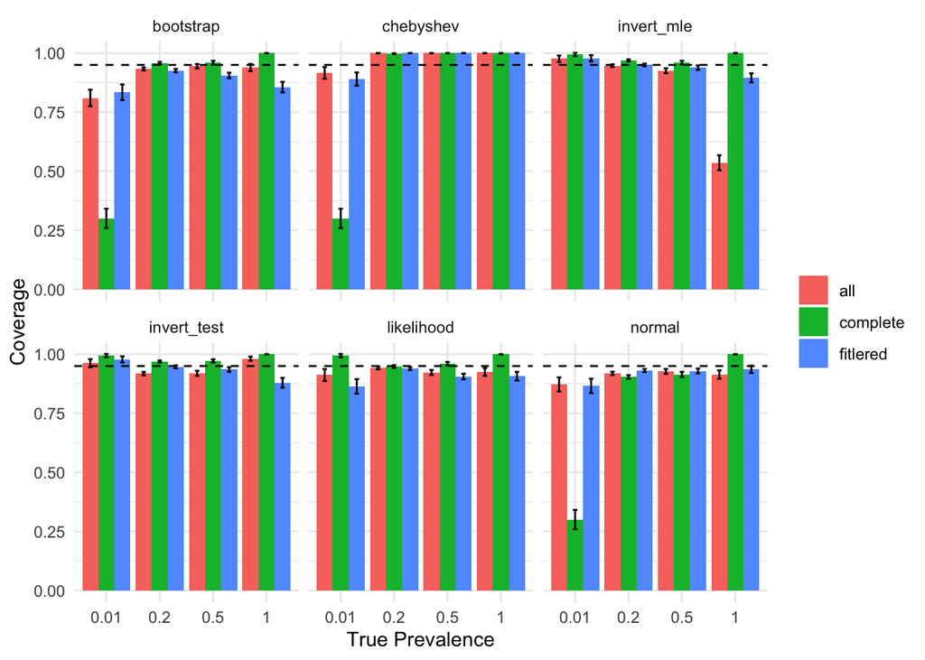

```r
ci_df_2 %>%
  group_by(method, variant, pi_true) %>%
  summarize(coverage = mean(covered, na.rm = TRUE),
            se = sqrt(coverage * (1-coverage) / n()),
            .groups = "drop") %>%
  ggplot(aes(x = factor(pi_true), y = coverage, fill = variant)) +
  geom_col(position = "dodge") +
  geom_errorbar(aes(ymin = coverage - 2 * se, ymax = coverage + 2 * se),
                position = position_dodge(width = 0.9), width = 0.25) +
  geom_hline(yintercept = 0.95, linetype = "dashed") +
  facet_wrap(~method) +
  labs(x = "True Prevalence", y = "Coverage", fill = NULL) +
  theme_minimal()
```

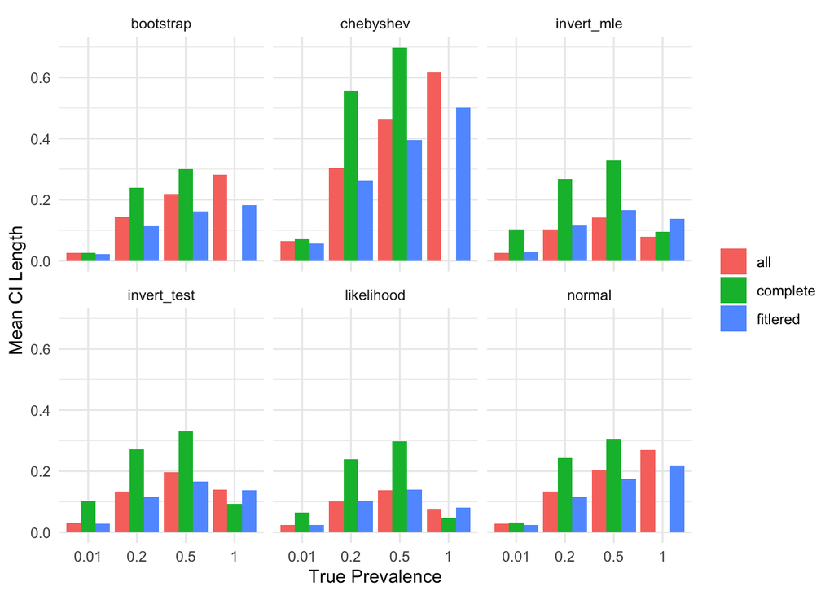

```r
ci_df_2 %>%
  group_by(method, variant, pi_true) %>%
  summarize(mean_length = mean(length, na.rm = TRUE), .groups = "drop") %>%
  ggplot(aes(x = factor(pi_true), y = mean_length, fill = variant)) +
  geom_col(position = "dodge") +
  facet_wrap(~method) +
  labs(x = "True Prevalence", y = "Mean CI Length", fill = NULL) +
  theme_minimal()
```

## 4.2 Detection Bias - Per Gene Missingness

Suppose that gene $j$ has a different chance of being missing than gene $j'$, with the behavior shared across all genes. Then instead of sampling $Z_{ij} \sim Bernoulli( \lambda_i)$ we would need to consider $Z_{ij} \sim Bernoulli( f_j(\lambda_i) )$ for some per gene function $f_j$. One example of this could be:

$$f_j(\lambda_i) = \text{ invlogit }( \delta_j \times \text{logit}(
\lambda_i ) )$$

where each $\delta_j \sim N( 0, \sigma^2 )$ for some chosen hyper-parameter $\sigma$.

```r
set.seed(123)
lambda <- c(rep(1, 40), rep(c(0.8, 0.6, 0.4, 0.2), each = 100))
pi <- c(rep(1, 1000), rep(0.5, 2500), rep(0.2, 6000), rep(0.01, 500))
sigma <- 0.2
delta <- rnorm(length(pi), 0, sigma)

logit <- function(x) {return(log(x / (1-x) ) )}
inv_logit <- function(x) {return(1/(1+exp(-x))) }

simulate_data_biased <- function(pi, lambda, delta) {
  n <- length(lambda)
  p <- length(pi)
  Y <- matrix(rbinom(n * p, 1, rep(pi, each = n)), nrow = n, ncol = p)
  Z_probs <- inv_logit( outer( logit(lambda), delta ) )
  Z <- matrix(rbinom(n * p, 1, Z_probs), nrow = n, ncol = p)
  list(X = Y * Z, Y = Y, Z = Z)
}

ex3 <- c(
  simulate_data_biased(pi, lambda, delta),
  pi = list(pi),
  lambda = list(lambda)
  )

ci_df_3 <- run_cis( ex3 )
```

```
## [1] "Normal CIs"
##    user  system elapsed
##   0.008   0.001   0.010
##    user  system elapsed
##   0.003   0.001   0.004
##    user  system elapsed
##   0.011   0.002   0.012
## [1] "Chebyshev CIs"
##    user  system elapsed
##   0.008   0.001   0.010
##    user  system elapsed
##   0.003   0.001   0.003
##    user  system elapsed
##   0.011   0.001   0.012
## [1] "Likelihood Ratio CIs"
##    user  system elapsed
## 276.578   8.060 285.093
##    user  system elapsed
## 143.275   2.082 145.648
##    user  system elapsed
## 246.361   6.733 253.511
## [1] "Exact Permutation CIs, using Unbiassed Est"
##    user  system elapsed
##  12.391   0.315  12.727
##    user  system elapsed
##   5.028   0.090   5.125
##    user  system elapsed
##  10.854   0.236  11.107
## [1] "Exact Permutation CIs, Using MLEs"
##    user  system elapsed
## 882.756  25.162 909.337
##    user  system elapsed
## 484.455   6.708 492.449
##    user  system elapsed
## 784.968  21.413 807.799
## [1] "Bootstrap CIs"
##    user  system elapsed
##  14.139   2.054  16.260
##    user  system elapsed
##   2.087   0.242   2.369
##    user  system elapsed
##  11.133   1.668  12.847
```

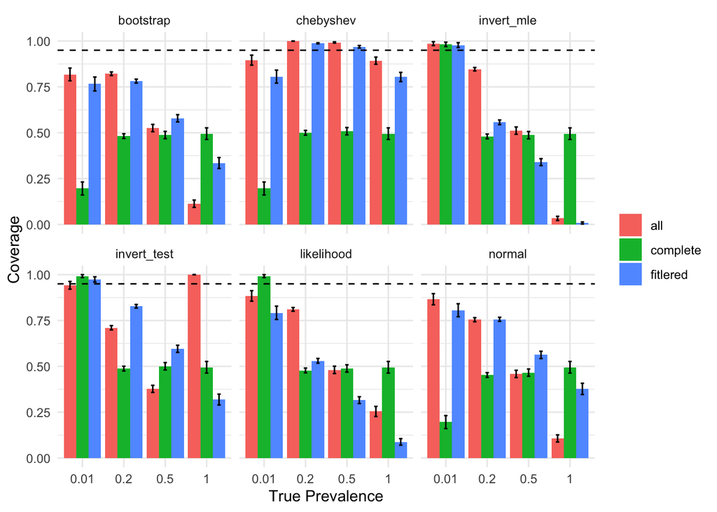

```r
ci_df_3 %>%
  group_by(method, variant, pi_true) %>%
  summarize(coverage = mean(covered, na.rm = TRUE),
            se = sqrt(coverage * (1-coverage) / n()),
            .groups = "drop") %>%
  ggplot(aes(x = factor(pi_true), y = coverage, fill = variant)) +
  geom_col(position = "dodge") +
  geom_errorbar(aes(ymin = coverage - 2 * se, ymax = coverage + 2 * se),
                position = position_dodge(width = 0.9), width = 0.25) +
  geom_hline(yintercept = 0.95, linetype = "dashed") +
  facet_wrap(~method) +
  labs(x = "True Prevalence", y = "Coverage", fill = NULL) +
  theme_minimal()
```

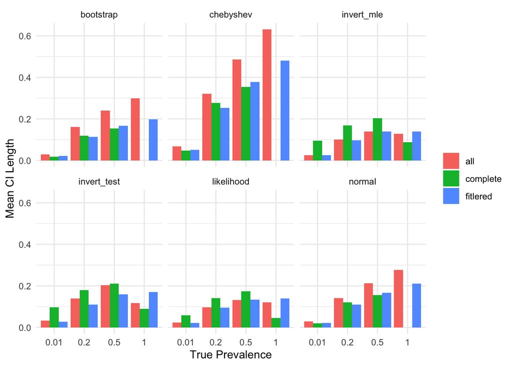

```r
ci_df_3 %>%
  group_by(method, variant, pi_true) %>%
  summarize(mean_length = mean(length, na.rm = TRUE), .groups = "drop") %>%
  ggplot(aes(x = factor(pi_true), y = mean_length, fill = variant)) +
  geom_col(position = "dodge") +
  facet_wrap(~method) +
  labs(x = "True Prevalence", y = "Mean CI Length", fill = NULL) +
  theme_minimal()
```

## 4.3 Per Gene Missingness from Gene Copies

Suppose now that each genome can exhibit multiple copies of gene $j$, and so the observed matrix has $\mathbb{P}( X_{ij} = 1) = \mathbb{P}( \text{More than one copy of gene } j \text{ and more than one observed})$. To model this, we assume that the gene copy number of gene $j$ in genome $i$ are poisson variables $C_{ij} - 1 \mid Y_{ij} = 1 \sim Poisson( 2 )$ , and now $Z_{ij} = 0$ if all $C_{ij}$ Bernoulli trials of probability $\lambda_i$ are $0$. This leads this is the mechanism that generates the following dataset.

```r
set.seed(123)
lambda <- c(rep(1, 40), rep(c(0.8, 0.6, 0.4, 0.2), each = 100))
pi <- c(rep(1, 1000), rep(0.5, 2500), rep(0.2, 6000), rep(0.01, 500))

simulate_data_gene_counts <- function(pi, lambda) {
  n <- length(lambda)
  p <- length(pi)
  Y <- matrix(rbinom(n * p, 1, rep(pi, each = n)), nrow = n, ncol = p)
  C <- 1 + matrix(rpois( n * p , 2 ), nrow = n, ncol = p)
  Z_counts <- matrix(rbinom(length(C), size = C, prob = rep(lambda, ncol(C))), nrow = nrow(C))
  Z <- Z_counts > 0
  list(X = Y * Z, Y = Y, Z = Z, C = C, K = Z_counts)
}

ex4 <- c(
  simulate_data_gene_counts(pi, lambda),
  pi = list(pi),
  lambda = list(lambda)
  )

ci_df_4 <- run_cis( ex4 )
```

```
## [1] "Normal CIs"
##    user  system elapsed
##   0.011   0.002   0.014
##    user  system elapsed
##   0.004   0.000   0.005
##    user  system elapsed
##   0.015   0.004   0.019
## [1] "Chebyshev CIs"
##    user  system elapsed
##   0.012   0.003   0.016
##    user  system elapsed
##   0.005   0.001   0.005
##    user  system elapsed
##   0.015   0.004   0.018
## [1] "Likelihood Ratio CIs"
##    user  system elapsed
## 373.606  21.046 397.389
##    user  system elapsed
## 194.429   6.503 201.551
##    user  system elapsed
## 327.459  18.019 347.559
## [1] "Exact Permutation CIs, using Unbiassed Est"
##    user  system elapsed
##  16.439   0.902  17.396
##    user  system elapsed
##   6.757   0.261   7.032
##    user  system elapsed
##  14.373   0.725  15.130
## [1] "Exact Permutation CIs, Using MLEs"
##     user   system  elapsed
## 1122.715   64.351 1191.251
##    user  system elapsed
## 571.981  15.594 588.199
##    user  system elapsed
## 911.392  49.355 962.213
## [1] "Bootstrap CIs"
##    user  system elapsed
##  16.346   3.598  20.015
##    user  system elapsed
##   2.704   0.514   3.235
##    user  system elapsed
##  13.624   3.228  17.075
```

To correct for the error caused by the missingness misspecification, we incorporate a correction using the mean gene copy number $c_j$ for each column. This is based on the (misspecified) log-likelihood of
$$\ell( \pi_j \mid X, \lambda, c_j ) = \sum_{i = 1}^n X_{ij} \log ( \pi_j
\tilde{\lambda}_i) + ( 1 - X_{ij} ) \log ( 1 - \pi_j \tilde{\lambda}_i
)$$
where $\tilde{\lambda_i} = 1 - (1 - \lambda_i)^{c_j}$. In this simulation, this is based on the true counts but in practice this may need to come from some estimate from the observed data.

```r
mean_gene_counts <- colMeans( ex4$K )

print(system.time({ ci_lr                 <- lr_ci(ex4$X, ex4$lambda, mean_gene_counts  ) }))
```

```
##    user  system elapsed
## 274.601   8.159 283.311
```

```r
print(system.time({ ci_lr_complete        <- lr_ci_complete(ex4$X, ex4$lambda, mean_gene_counts ) }))
```

```
##    user  system elapsed
## 145.390   2.175 147.852
```

```r
print(system.time({ ci_lr_filtered        <- lr_ci_filtered(ex4$X, ex4$lambda, mean_gene_counts ) }))
```

```
##    user  system elapsed
## 243.925   6.788 251.153
```

```r
ci_df_5 <- bind_rows(
  make_ci_df(ci_lr,                     "likelihood_counts",  "all",      ex4$pi),
  make_ci_df(ci_lr_complete,            "likelihood_counts",  "complete", ex4$pi),
  make_ci_df(ci_lr_filtered,            "likelihood_counts",  "filtered", ex4$pi)
)
```

Alternatively we can correct by using the mean $\tilde{\lambda}_i = \frac{1}{n} \sum_{j = 1}^n 1 - (1 - \lambda_i)^{K_{ij}}$, i.e.

```r
lambda_mat <- matrix( ex4$lambda, nrow = nrow(ex4$X), ncol = ncol(ex4$X) )

lambda_tildes <- 1 - (1 - lambda_mat)^ex4$K

print(system.time({ ci_lr                 <- lr_ci(ex4$X, lambda_tildes ) }))
```

```
##    user  system elapsed
## 270.936   8.241 279.766
```

```r
print(system.time({ ci_lr_complete        <- lr_ci_complete(ex4$X, lambda_tildes ) }))
```

```
##    user  system elapsed
## 144.795   2.335 147.408
```

```r
print(system.time({ ci_lr_filtered        <- lr_ci_filtered(ex4$X, lambda_tildes ) }))
```

```
##    user  system elapsed
## 145.251   2.329 147.866
```

```r
ci_df_6 <- bind_rows(
  make_ci_df(ci_lr,                     "likelihood_lambdas",  "all",      ex4$pi),
  make_ci_df(ci_lr_complete,            "likelihood_lambdas",  "complete", ex4$pi),
  make_ci_df(ci_lr_filtered,            "likelihood_lambdas",  "filtered", ex4$pi)
)
```

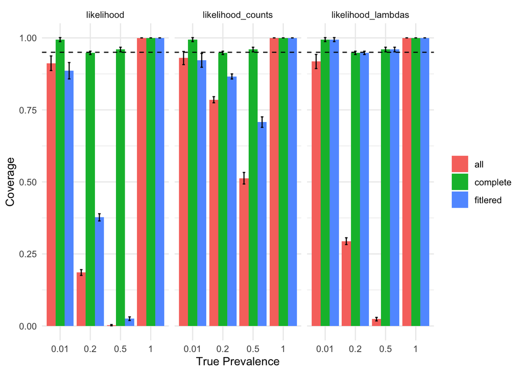

```r
ci_df_7 <- bind_rows( ci_df_4, ci_df_5, ci_df_6 )

ci_df_7 %>%
  group_by(method, variant, pi_true) %>%
  filter( method %in% c("likelihood", "likelihood_counts", "likelihood_lambdas") ) %>%
  summarize(coverage = mean(covered, na.rm = TRUE),
            se = sqrt(coverage * (1-coverage) / n()),
            .groups = "drop") %>%
  ggplot(aes(x = factor(pi_true), y = coverage, fill = variant)) +
  geom_col(position = "dodge") +
  geom_errorbar(aes(ymin = coverage - 2 * se, ymax = coverage + 2 * se),
                position = position_dodge(width = 0.9), width = 0.25) +
  geom_hline(yintercept = 0.95, linetype = "dashed") +
  facet_wrap(~method) +
  labs(x = "True Prevalence", y = "Coverage", fill = NULL) +
  theme_minimal()
```

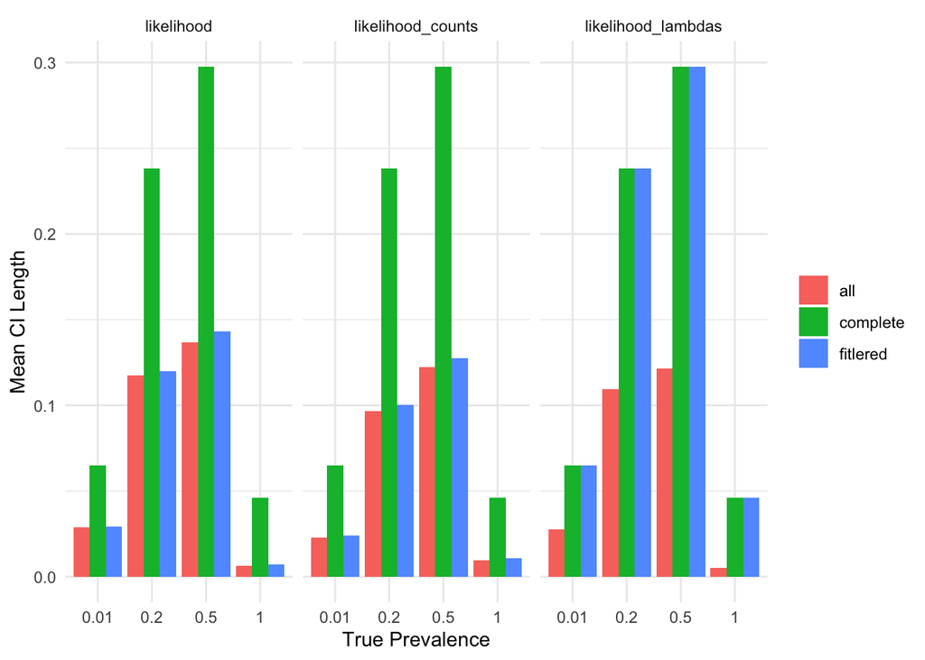

```r
ci_df_7 %>%
  group_by(method, variant, pi_true) %>%
  filter( method %in% c("likelihood", "likelihood_counts", "likelihood_lambdas") ) %>%
  summarize(mean_length = mean(length, na.rm = TRUE), .groups = "drop") %>%
  ggplot(aes(x = factor(pi_true), y = mean_length, fill = variant)) +
  geom_col(position = "dodge") +
  facet_wrap(~method) +
  labs(x = "True Prevalence", y = "Mean CI Length", fill = NULL) +
  theme_minimal()
```

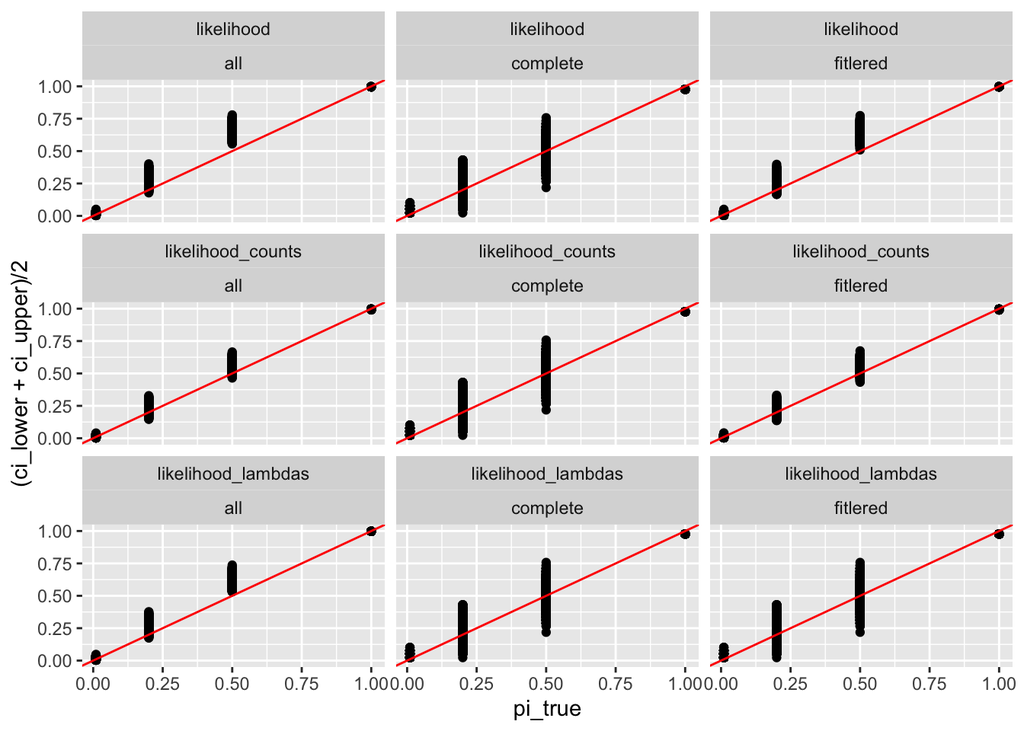

```r
ci_df_7 %>%
  filter(method %in% c("likelihood", "likelihood_counts", "likelihood_lambdas")) %>%
  ggplot(aes(x = pi_true, y = (ci_lower + ci_upper) / 2, ymin = ci_lower, ymax = ci_upper)) +
  geom_point() +
  # geom_errorbar() +
  geom_abline(slope = 1, intercept = 0, colour = "red") +
  facet_wrap( method ~ variant )
```

# 5 Combining Confidence Intervals

Consider now the case that we have $k = 1, \dots, K$ sub-communities and have fitted estimates of the prevalence $\widehat{\pi}_j^{(k)}$ and $(1-\alpha)$-confidence intervals of the form $[L_j^{(k)}, U_j^{(k)}]$ for each gene $j$ in each sub-community $k$ independently. Suppose that we are interested in the prevalence of gene $j$ in some community with composition $( p_1, \dots, p_K)$ with $p_k >0$ and $\sum p_k = 1$. How should we combine these estimates and confidence intervals to understand $\pi_j$?

We will run some simulations for this set-up with 5 sub communities with differing prevalences of their genes.

```r
set.seed(123)
lambda_1 <- rep(c(1.0, 0.8, 0.6, 0.4, 0.2), each = 20)
pi_1 <- c(rep(1, 100), rep(0.4, 250), rep(0.3, 600), rep(0.02, 50))
pop1 <- c(
  simulate_data(pi_1, lambda_1),
  pi = list(pi_1),
  lambda = list(lambda_1)
  )


lambda_2 <- rep(c(1.0, 0.8, 0.6, 0.4, 0.2), each = 50)
pi_2 <- c(rep(1, 100), rep(0.5, 250), rep(0.2, 600), rep(0.03, 50))
pop2 <- c(
  simulate_data(pi_2, lambda_2),
  pi = list(pi_2),
  lambda = list(lambda_2)
  )


lambda_3 <- rep(c(1.0, 0.8, 0.6, 0.4, 0.2), each = 10)
pi_3 <- c(rep(1, 100), rep(0.6, 250), rep(0.15, 600), rep(0.04, 50))
pop3 <- c(
  simulate_data(pi_3, lambda_3),
  pi = list(pi_3),
  lambda = list(lambda_3)
  )


lambda_4 <- c(rep(1.0, 60), rep(c(0.8, 0.6, 0.4, 0.2), each = 20) )
pi_4 <- c(rep(1, 100), rep(0.7, 250), rep(0.25, 600), rep(0.01, 50))
pop4 <- c(
  simulate_data(pi_4, lambda_4),
  pi = list(pi_4),
  lambda = list(lambda_4)
  )


lambda_5 <- rep(c(1.0, 0.8, 0.6, 0.4, 0.2), each = 40)
pi_5 <- c(rep(1, 100), rep(0.8, 250), rep(0.1, 600), rep(0.02, 50))
pop5 <- c(
  simulate_data(pi_5, lambda_5),
  pi = list(pi_5),
  lambda = list(lambda_5)
  )
```

## 5.1 Estimates of $\pi_j$

```r
pi_hats <- matrix(0, nrow = 5, ncol = length( pi_1 ) )

pi_hats[1,] <- estimate_pi( pop1$X, pop1$lambda )
pi_hats[2,] <- estimate_pi( pop2$X, pop2$lambda )
pi_hats[3,] <- estimate_pi( pop3$X, pop3$lambda )
pi_hats[4,] <- estimate_pi( pop4$X, pop4$lambda )
pi_hats[5,] <- estimate_pi( pop5$X, pop5$lambda )
```

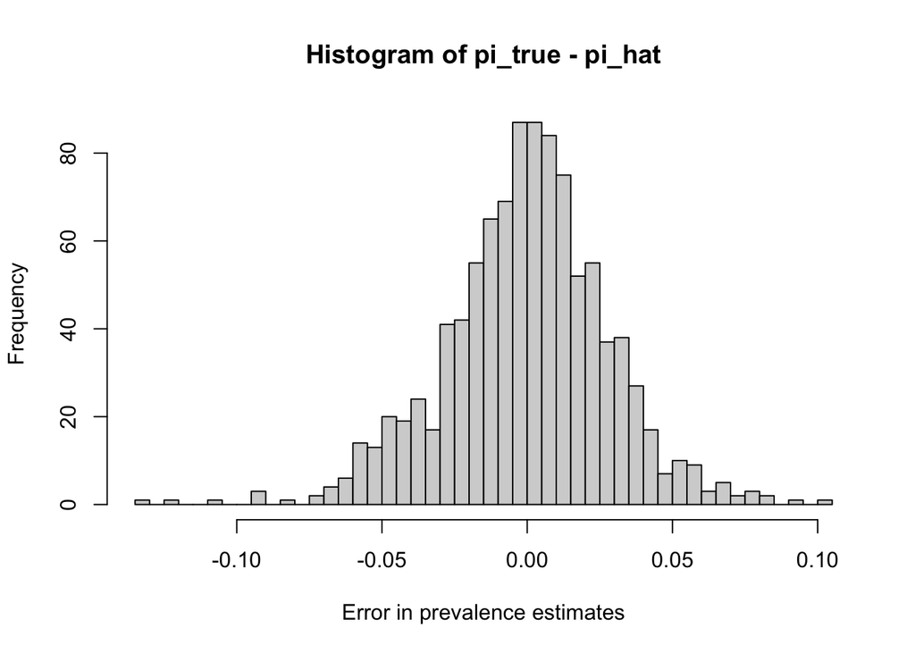

```r
counts <- c( length(pop1$lambda),
             length(pop2$lambda),
             length(pop3$lambda),
             length(pop4$lambda),
             length(pop5$lambda) )
proportions <- counts / sum(counts)

pis_true <- rbind( pop1$pi, pop2$pi, pop3$pi, pop4$pi, pop5$pi  )
pi_true <- proportions %*% pis_true

pi_hat <- proportions %*% pi_hats

hist( pi_true - pi_hat, breaks = 50, xlab = "Error in prevalence estimates" )
```

## 5.2 Confidence Intervals

We will now demonstrate some methods of combining confidence intervals for $\pi_j$.

### 5.2.1 Combined Variance CI

The first is to use the weighted average of the simple estimator on each sub-population. Writing $V_j^{(k)} = Var( \widehat{\pi}_j^{(k)} )$ we have that

$$Var( \widehat{\pi}_j ) = Var( \sum_k \widehat{\pi}_j^{(k)} p_k ) =
\sum_k p_k^2 V_j^{(k)}$$

Thus we can take the sum $\sum_k p_k^2 \widehat{V}_j^{(k)}$ as an estimate of this variance and take Chebyshev confidence intervals around the estimates $\widehat{\pi}_j$.

```r
combined_cheb_ci <- function( datalist, proportions, alpha = 0.05 ) {
  n_genes <- dim( datalist[[1]]$X )[2]
  n_populations <- length( proportions )

  pi_hats <- matrix( 0, nrow = n_populations, ncol = n_genes )
  var_hats <- matrix( 0, nrow = n_populations, ncol = n_genes )

  for ( k in 1:n_populations ) {
    dataset <- datalist[[k]]
    pi_hats[k,] <- estimate_pi( dataset$X, dataset$lambda )
    var_hats[k,] <- estimate_pi_var( dataset$X, dataset$lambda, pi_hats[k,] )
  }

  combined_pi <- proportions %*% pi_hats
  combined_vars <- ( proportions^2 ) %*% var_hats
  half_widths <- sqrt( combined_vars / alpha )
  return( list(lower = as.vector( pi_hat - half_widths ), upper = as.vector( pi_hat + half_widths ) ) )
}
```

### 5.2.2 Guaranteed Combinations of Black Box CIs

Instead we can consider how to combine the “black box” $(1-\alpha)$ confidence intervals for each $\pi_j^{(k)}$ of the form $[ L_j^{(k)}, U_j^{(k)} ]$. The probability of the vector $\pi_j = [ \pi_j^{(1)}, \dots, \pi_j^{(K)}]$ being in the hypercube $Box = \prod_{k = 1}^K [ L_j^{(k)}, U_j^{(k)} ]$ is $(1 - \alpha)^K$ by the independence of each confidence interval. Taking $L_j = \inf_{\pi \in Box} \pi^T p = \sum_{k =1 }^K p_k L_j^{(k)}$ and $U_j = \sup_{\pi \in Box} \pi^T p = \sum_{k =1 }^K p_k U_j^{(k)}$ thus gives a $(1 - \alpha)^K$ confidence interval for the combined prevalence $\pi_j$. If we want a $(1- \alpha)$-confidence interval for this prevalence, we thus therefor form the sub-population confidence intervals at the $(1 - (1-\alpha)^{1/K})$ significance level. We will call this the guaranteed combined confidence interval.

If we were to ignore this significance level correction we will call this the uncorrected likelihood confidence interval.

Both of these methods of combination can be used for any of the Likelihood ratio CIs, the Bootstrap CIs, or the invert-exact CIs.

```r
combined_cis <- function( datalist, proportions, alpha = 0.05, ci_method = lr_ci, corrected = TRUE ) {
  n_genes <- dim( datalist[[1]]$X )[2]
  n_populations <- length( proportions )
  a <- alpha
  if (corrected) { a <- 1 - (1 - alpha)^{1/n_populations} }

  lowers <- matrix( 0, nrow = n_populations, ncol = n_genes )
  uppers <- matrix( 0, nrow = n_populations, ncol = n_genes )

  for ( k in 1:n_populations ) {
    dataset <- datalist[[k]]
    lr_ci_k <- ci_method( dataset$X, dataset$lambda, alpha = a )
    lowers[k,] <- lr_ci_k$lower
    uppers[k,] <- lr_ci_k$upper
  }

  combined_lower <- proportions %*% lowers
  combined_upper <- proportions %*% uppers
  return( list(lower = as.vector( combined_lower ), upper = as.vector( combined_upper ) ) )
}
```

### 5.2.3 Approximate Variance Likelihood CI

```r
approx_variance_likelihoods <- function( datalist, proportions, alpha = 0.05, ci_method = lr_ci ) {
  n_genes <- dim( datalist[[1]]$X )[2]
  n_populations <- length( proportions )

  pi_hats <-  matrix( 0, nrow = n_populations, ncol = n_genes )
  lowers <- matrix( 0, nrow = n_populations, ncol = n_genes )
  uppers <- matrix( 0, nrow = n_populations, ncol = n_genes )

  for ( k in 1:n_populations ) {
    dataset <- datalist[[k]]
    pi_hats[k,] <- estimate_pi_mle_optim( dataset$X, dataset$lambda )$pi_hats
    lr_ci_k <- ci_method( dataset$X, dataset$lambda, alpha = alpha )
    lowers[k,] <- lr_ci_k$lower
    uppers[k,] <- lr_ci_k$upper
  }

  c_alpha <- qnorm(1 - alpha/2)
  half_widths <- (uppers - lowers) / 2
  var_hats <- ( half_widths / c_alpha )^2

  combined_var_hats <- ( proportions^2 ) %*% var_hats
  combined_pi_hats <- proportions %*% pi_hats

  combined_lower <- combined_pi_hats - c_alpha * sqrt( combined_var_hats )
  combined_upper <- combined_pi_hats + c_alpha * sqrt( combined_var_hats )
  return( list(lower = as.vector( combined_lower ), upper = as.vector( combined_upper ) ) )
}
```

## 5.3 Comparing these methods

We can compare these four methods on the same dataset as above, using the same plots as in the previous sections.

```r
datalist = list( pop1, pop2, pop3, pop4, pop5 )
counts <- c( length(pop1$lambda),
             length(pop2$lambda),
             length(pop3$lambda),
             length(pop4$lambda),
             length(pop5$lambda) )
proportions <- counts / sum(counts)

pis_true <- rbind( pop1$pi, pop2$pi, pop3$pi, pop4$pi, pop5$pi  )
pi_true <- as.vector( proportions %*% pis_true )
unique_pis <- unique( pi_true )

system.time( cis_cheb <- combined_cheb_ci( datalist, proportions ) )
```

```
##    user  system elapsed
##   0.011   0.001   1.324
```

```r
system.time( cis_likelihood <- combined_cis( datalist, proportions ) )
```

```
##    user  system elapsed
##  95.736   2.366  99.281
```

```r
system.time( cis_likelihood_uncorrected <- combined_cis( datalist, proportions, corrected = FALSE ) )
```

```
##    user  system elapsed
## 100.466   2.759 105.598
```

```r
system.time( cis_likelihood_approx_var <- approx_variance_likelihoods( datalist, proportions ) )
```

```
##    user  system elapsed
## 101.891   2.581 106.101
```

```r
system.time( cis_invert_exact <- combined_cis( datalist, proportions, ci_method = invert_test_ci ) )
```

```
##    user  system elapsed
##  37.035   0.942  38.333
```

```r
system.time( cis_invert_exact_uncorrected <- combined_cis( datalist, proportions, ci_method = invert_test_ci, corrected = FALSE ) )
```

```
##    user  system elapsed
##  37.745   0.960  39.125
```

```r
system.time( cis_invert_exact_approx_var <- approx_variance_likelihoods( datalist, proportions, ci_method = invert_test_ci ) )
```

```
##    user  system elapsed
##  41.775   1.083  43.649
```

```r
system.time( cis_bootstrap <- combined_cis( datalist, proportions, ci_method = bootstrap_ci ) )
```

```
##    user  system elapsed
##   3.020   0.584   3.746
```

```r
system.time( cis_bootstrap_uncorrected  <- combined_cis( datalist, proportions, ci_method = bootstrap_ci, corrected = FALSE ) )
```

```
##    user  system elapsed
##   2.997   0.555   3.622
```

```r
system.time( cis_bootstrap_approx_var <- approx_variance_likelihoods( datalist, proportions, ci_method = bootstrap_ci ) )
```

```
##    user  system elapsed
##   6.389   0.707   7.299
```

```r
combined_ci_df <- bind_rows(
  make_ci_df(cis_cheb,                     "Chebyshev",      "Basic",          pi_true ),
  make_ci_df(cis_likelihood,               "Likelihood",     "Guaranteed",     pi_true ),
  make_ci_df(cis_likelihood_uncorrected,   "Likelihood",     "Uncorrected",    pi_true ),
  make_ci_df(cis_likelihood_approx_var,    "Likelihood",     "Approx. Var.",   pi_true ),
  make_ci_df(cis_invert_exact,             "Invert Exact",   "Guaranteed",     pi_true ),
  make_ci_df(cis_invert_exact_uncorrected, "Invert Exact",   "Uncorrected",    pi_true ),
  make_ci_df(cis_invert_exact_approx_var,  "Invert Exact",   "Approx. Var.",   pi_true ),
  make_ci_df(cis_bootstrap,                "Bootstrap",      "Guaranteed",     pi_true ),
  make_ci_df(cis_bootstrap_uncorrected,    "Bootstrap",      "Uncorrected",    pi_true ),
  make_ci_df(cis_bootstrap_approx_var,     "Bootstrap",      "Approx. Var.",   pi_true ) )
```

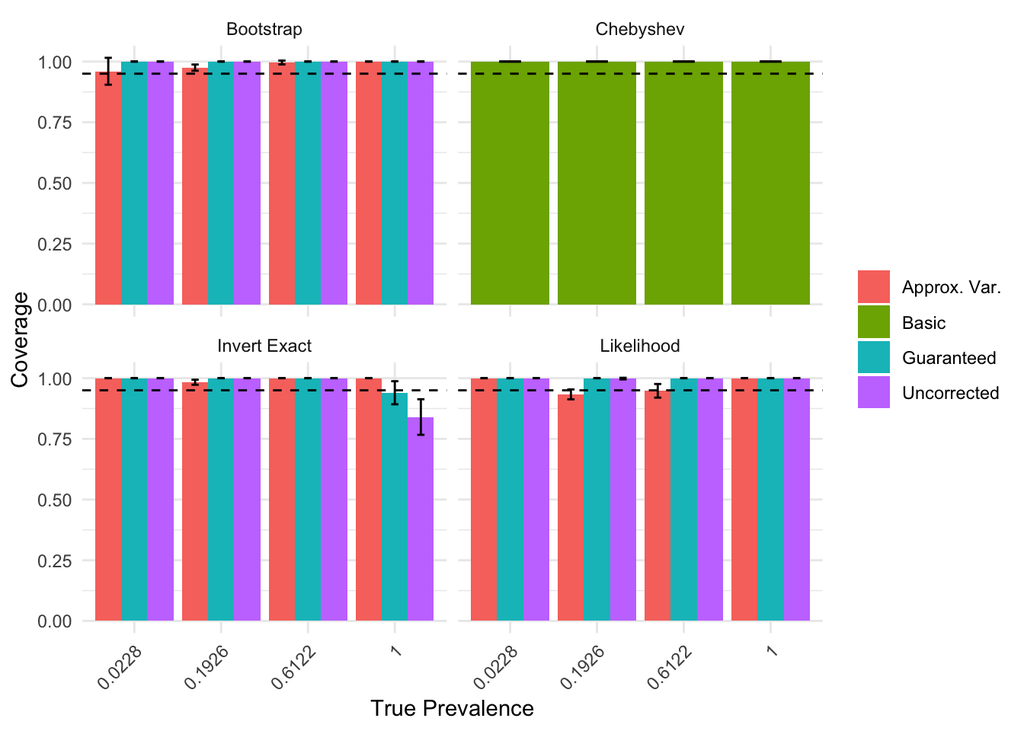

```r
combined_ci_df %>%
  group_by(method, variant, pi_true) %>%
  summarize(coverage = mean(covered, na.rm = TRUE),
            se = sqrt(coverage * (1-coverage) / n()),
            .groups = "drop") %>%
  ggplot(aes(x = factor(round(pi_true,4)), y = coverage, fill = variant)) +
  geom_col(position = "dodge") +
  geom_errorbar(aes(ymin = coverage - 2 * se, ymax = coverage + 2 * se),
                position = position_dodge(width = 0.9), width = 0.25) +
  geom_hline(yintercept = 0.95, linetype = "dashed") +
  facet_wrap(~method) +
  labs(x = "True Prevalence", y = "Coverage", fill = NULL) +
  theme_minimal() +
  theme(axis.text.x = element_text(angle = 45, hjust = 1))
```

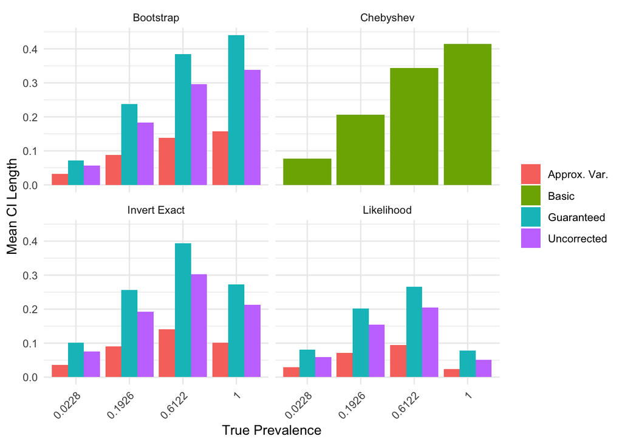

```r
combined_ci_df %>%
  group_by(method, variant, pi_true) %>%
  summarize(mean_length = mean(length, na.rm = TRUE), .groups = "drop") %>%
  ggplot(aes(x = factor(round(pi_true,4)), y = mean_length, fill = variant)) +
  geom_col(position = "dodge") +
  facet_wrap(~method) +
  labs(x = "True Prevalence", y = "Mean CI Length", fill = NULL) +
  theme_minimal() +
  theme(axis.text.x = element_text(angle = 45, hjust = 1))
```

Of the options that provide empirical coverage, the Approximate Variance Likelihood ratio confidence intervals have the shortest average lengths across the possible prevalences. This is particularly true for the core genes with $\pi_j = 1$, so this option will have the best ability to discern core from non-core genes.

Note that even though this method has a lower than $1-\alpha$ proportion of confidence intervals containing the true parameter for the semi-rare $\pi_j$, this does not deviate from significantly from the behavior we would expect from random chance in finite simulations under the null hypothesis of valid coverage at the $1-\alpha$ significance level.

# 6 Conclusions

Overall, using the MLE leads to lower mean squared error estimates of the underlying prevalences, and leads to narrower confidence intervals. This is mostly because it is less thrown off by low completeness genomes, and is able to still use the information in that data. However, it is affected by the cases where genes are not observed and we should consider how we want to treat these cases.

Parts of this file was generated using Claude Code.

[output not shown]

[^1]: It is estimated based on the proportion of “core genes” that are detected in genome $i$, but we treat it for this analysis as known.